# Predicting recall RT with 2AFC RT (v2.0)

Mar 3, 2021

### Exclusions

- Excluding 0 participants who gave incorrect resonses on fewer than 25% of recall trials, leaving 30 participants in the analysis.
- Dropping 29 recall trials with reaction times over more than 3 sds above the mean (more than 5.6 seconds), leaving 541 trials in the analysis.

## AFC RT -> Recall RT

We want to see if the reaction time on 2AFC trials for a given word are predictive of reaction time for the same word in the recall task.

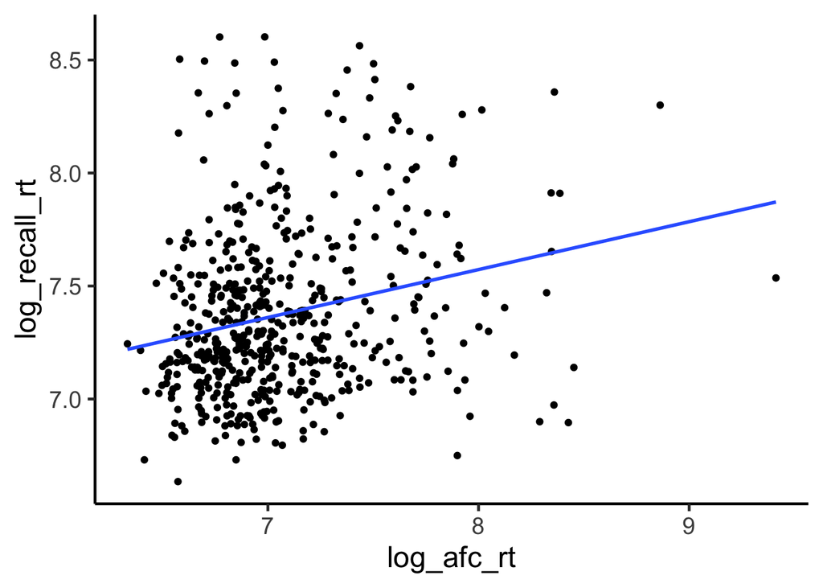

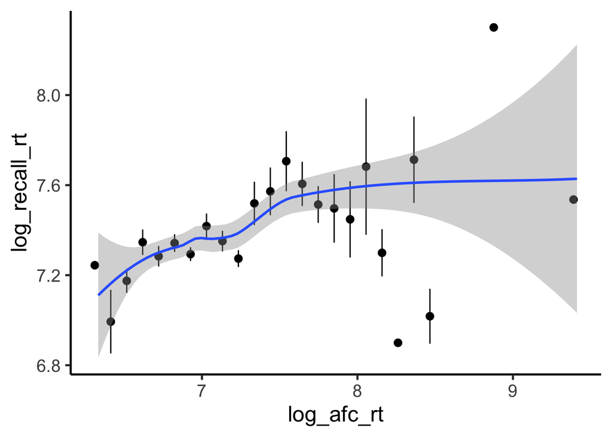

|  | Est. | S.E. | t val. | p |
| --- | --- | --- | --- | --- |
| (Intercept) | 5.878 | 0.270 | 21.766 | 0.000 |
| log_afc_rt | 0.212 | 0.038 | 5.550 | 0.000 |

Standard errors: OLS

This looks promising, but it could be driven by individual differences. We need to see the effect within individuals.

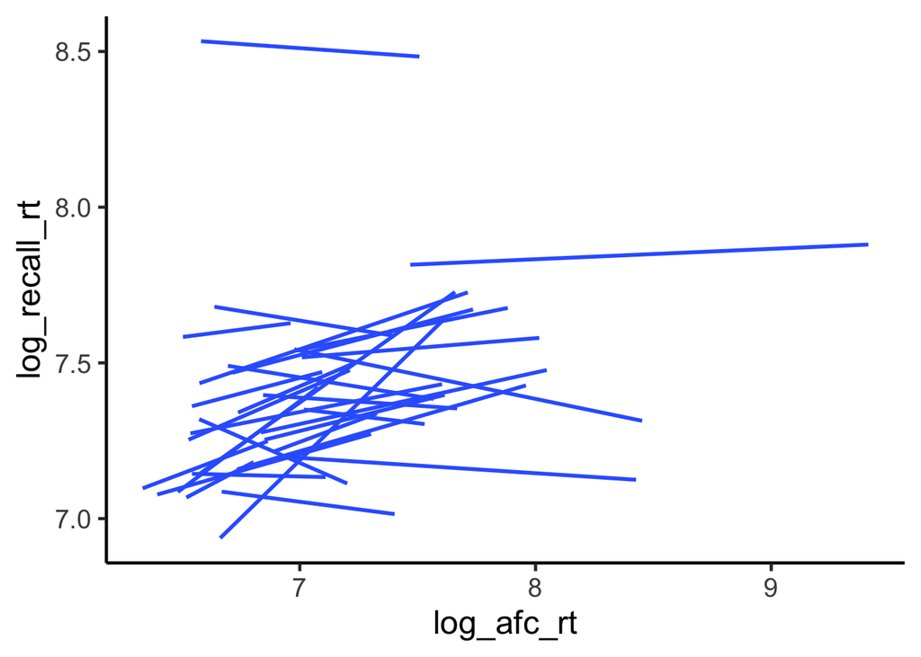

| Fixed Effects | Fixed Effects Est. | Fixed Effects S.E. | Fixed Effects t val. | Fixed Effects d.f. | Fixed Effects p |
| --- | --- | --- | --- | --- | --- |
| (Intercept) | 6.457 | 0.356 | 18.139 | 448.779 | 0.000 |
| log_afc_rt | 0.133 | 0.050 | 2.655 | 470.040 | 0.008 |

p values calculated using Satterthwaite d.f.

Looks like we still see a positive relationship. We can visualize it more clearly by applying participant-wise mean centering:

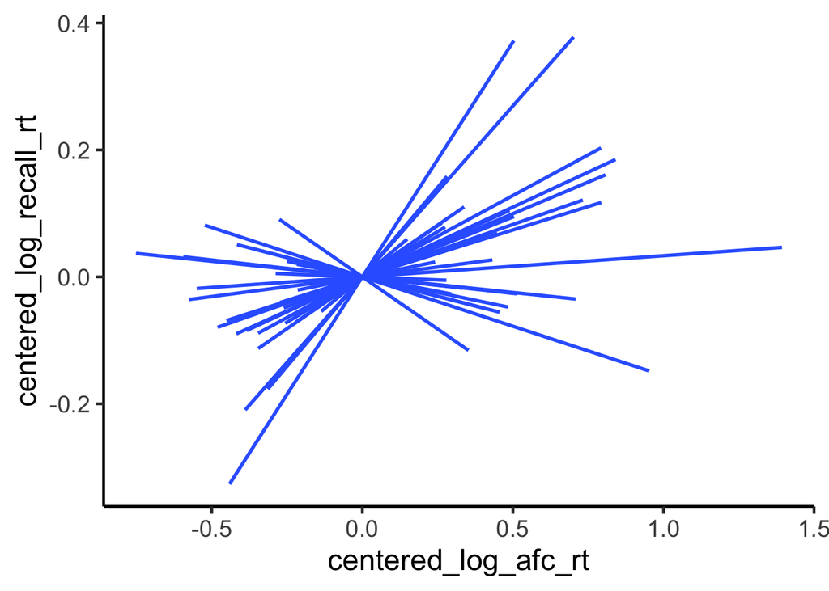

And here is the distribution of slopes (with 95% confidence intervals).

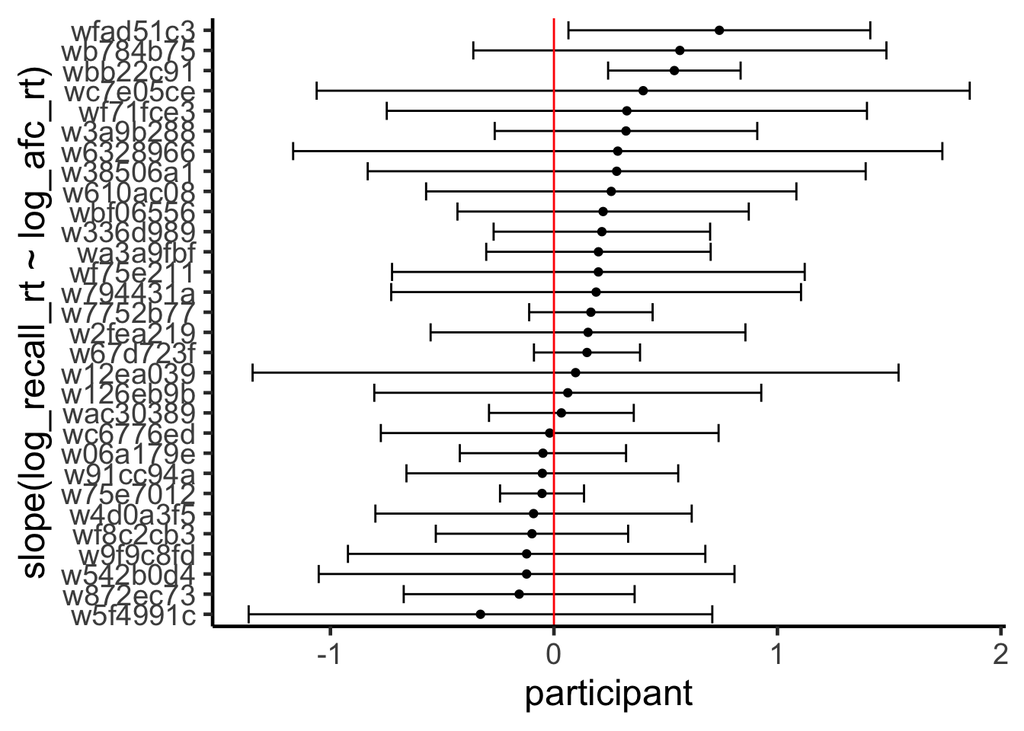

67% of participants have a positive slope. This is a good sign, but it’s still not great. The estimates are super noisy so it’s hard to know how much of this is real. Here’s a similar plot with the correlation.

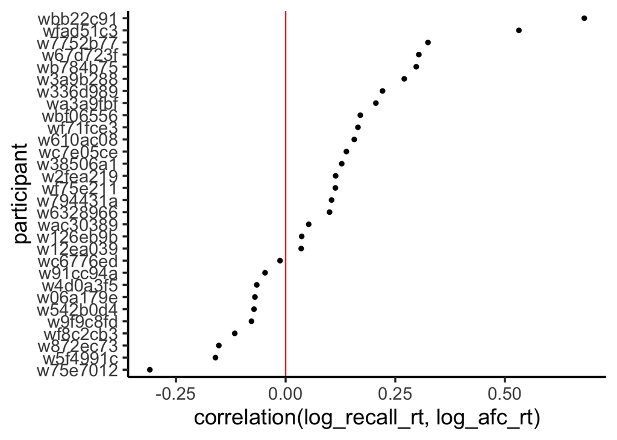

## AFC accuracy

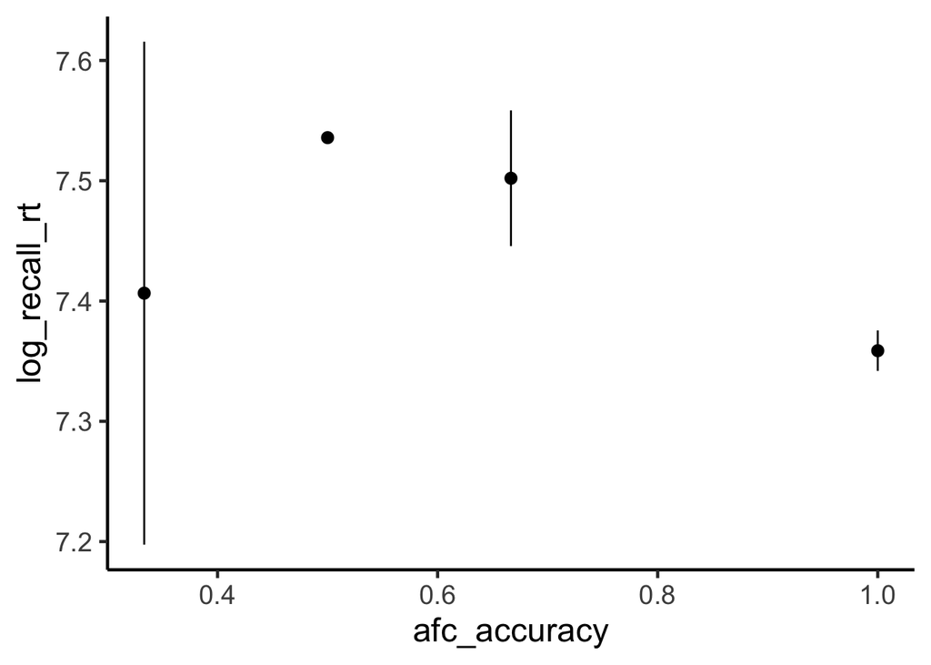

|  | Est. | S.E. | t val. | p |
| --- | --- | --- | --- | --- |
| (Intercept) | 7.693 | 0.129 | 59.536 | 0.000 |
| afc_accuracy | -0.333 | 0.134 | -2.486 | 0.013 |

Standard errors: OLS

This looks promising, but it turns out this one is driven entirely by individual differences (each line is a participant). Mixed effects regression shows no effect of 2AFC trials, especially when we account for RT on the correct 2AFC trials.

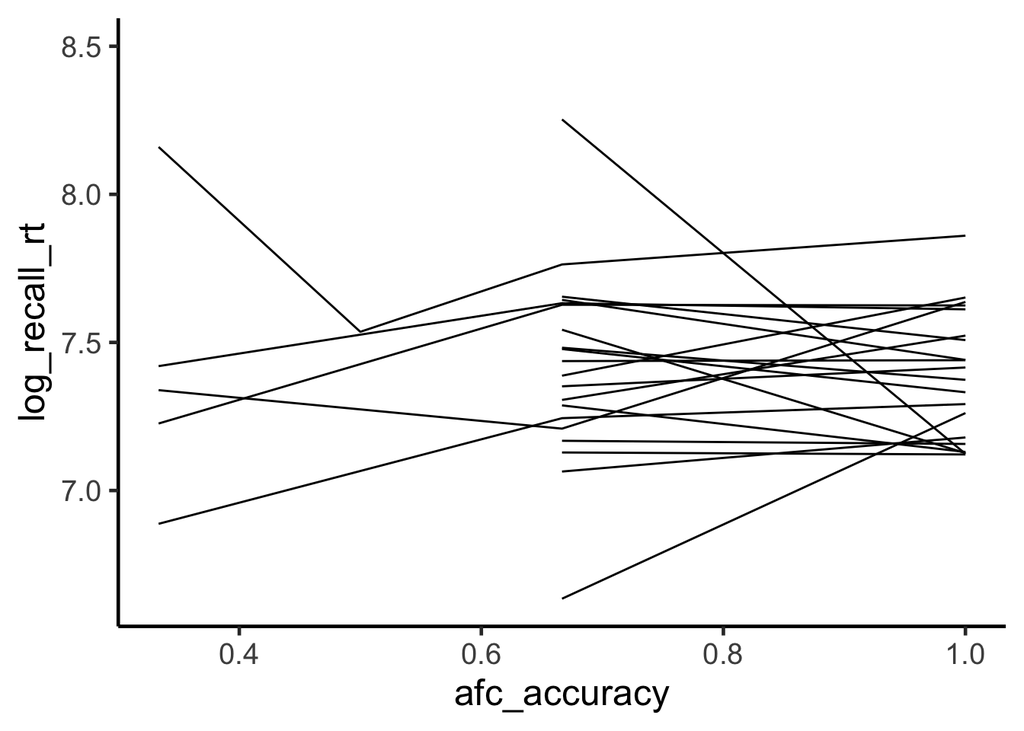

| Fixed Effects | Fixed Effects Est. | Fixed Effects S.E. | Fixed Effects t val. | Fixed Effects d.f. | Fixed Effects p |
| --- | --- | --- | --- | --- | --- |
| (Intercept) | 7.418 | 0.129 | 57.555 | 446.108 | 0.000 |
| afc_accuracy | -0.025 | 0.125 | -0.197 | 526.788 | 0.844 |

p values calculated using Satterthwaite d.f.

| Fixed Effects | Fixed Effects Est. | Fixed Effects S.E. | Fixed Effects t val. | Fixed Effects d.f. | Fixed Effects p |
| --- | --- | --- | --- | --- | --- |
| (Intercept) | 6.462 | 0.385 | 16.802 | 480.218 | 0.000 |
| afc_accuracy | -0.005 | 0.125 | -0.036 | 526.201 | 0.971 |
| log_afc_rt | 0.133 | 0.050 | 2.644 | 470.749 | 0.008 |

p values calculated using Satterthwaite d.f.

## Time course

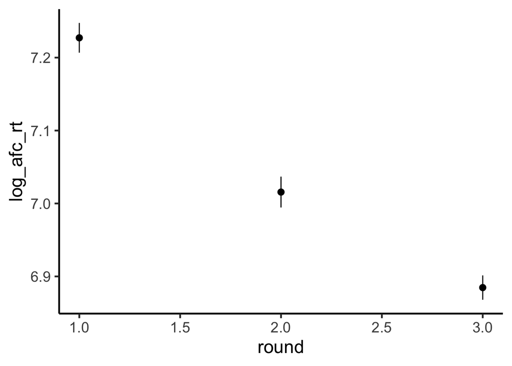

2AFC RT goes down, as we would expect.

| Fixed Effects | Fixed Effects Est. | Fixed Effects S.E. | Fixed Effects t val. | Fixed Effects d.f. | Fixed Effects p |
| --- | --- | --- | --- | --- | --- |
| (Intercept) | 6.154 | 0.433 | 14.214 | 398.074 | 0.000 |
| log_afc_rt1 | 0.062 | 0.040 | 1.530 | 508.449 | 0.127 |
| log_afc_rt2 | 0.054 | 0.047 | 1.167 | 496.550 | 0.244 |
| log_afc_rt3 | 0.060 | 0.049 | 1.224 | 509.935 | 0.222 |

p values calculated using Satterthwaite d.f.

The slope appears to be constant over rounds.

| lo | g_afc_rt1 lo | g_afc_rt2 lo | g_afc_rt3 lo | g_recall_rt |
| --- | --- | --- | --- | --- |
| log_afc_rt1 | 1.0000000 | 0.3954083 | 0.3235148 | 0.1382458 |
| log_afc_rt2 | 0.3954083 | 1.0000000 | 0.6097865 | 0.2016508 |
| log_afc_rt3 | 0.3235148 | 0.6097865 | 1.0000000 | 0.1877160 |
| log_recall_rt | 0.1382458 | 0.2016508 | 0.1877160 | 1.0000000 |

But the correlation is higher in rounds 2 and 3. (Look at the last column in the correlation matrix)

# Word type effects

## Accuracy

### All participants (before exclusion)

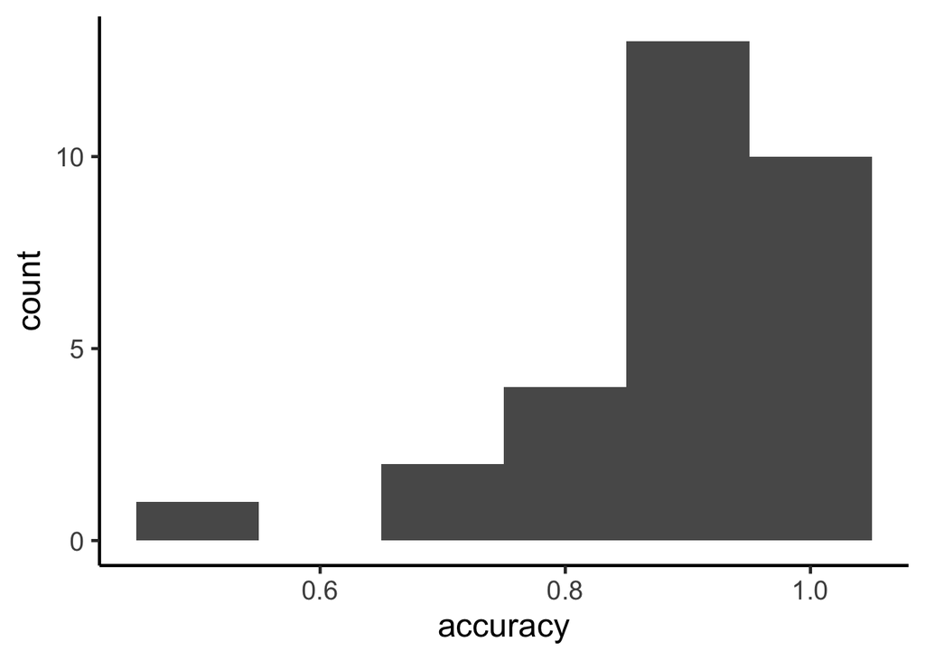

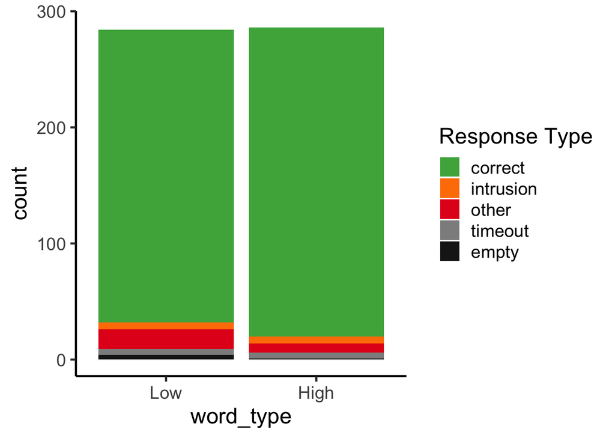

### Good participants (after exclusion)

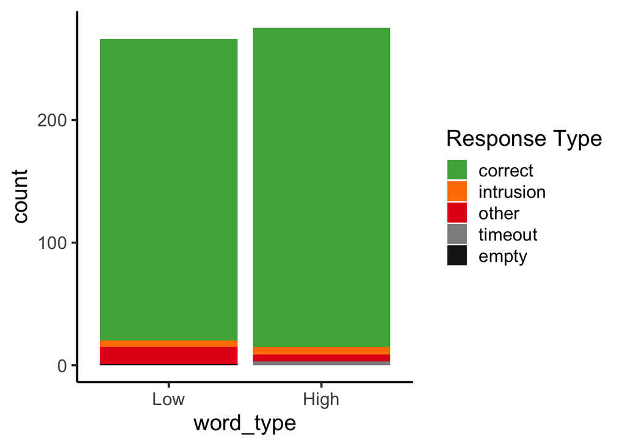

```r
glmer(correct ~ word_type + (1|wid), data=trials, family=binomial) %>% summ
```

| Fixed Effects | Fixed Effects Est. | Fixed Effects S.E. | Fixed Effects z val. | Fixed Effects p |
| --- | --- | --- | --- | --- |
| (Intercept) | 2.918 | 0.353 | 8.277 | 0.000 |
| word_typeHigh | 0.386 | 0.370 | 1.044 | 0.297 |

## Reaction time

### Aggregate

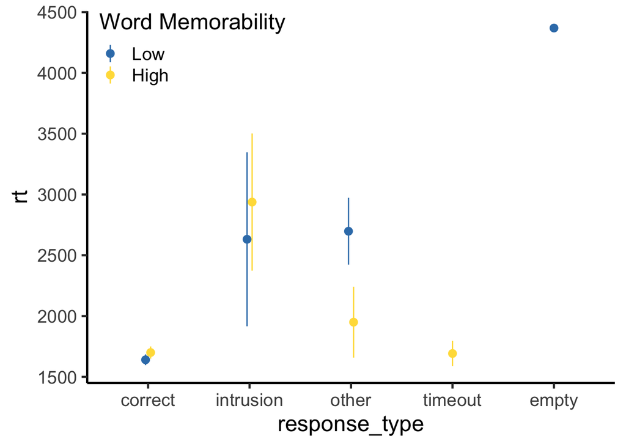

| response_type | word_type | rt |
| --- | --- | --- |
| correct | Low | 1640.431 |
| correct | High | 1699.942 |
| intrusion | Low | 2631.400 |
| intrusion | High | 2937.500 |
| other | Low | 2697.786 |
| other | High | 1949.667 |
| timeout | High | 1692.000 |
| empty | Low | 4369.000 |

### By participant

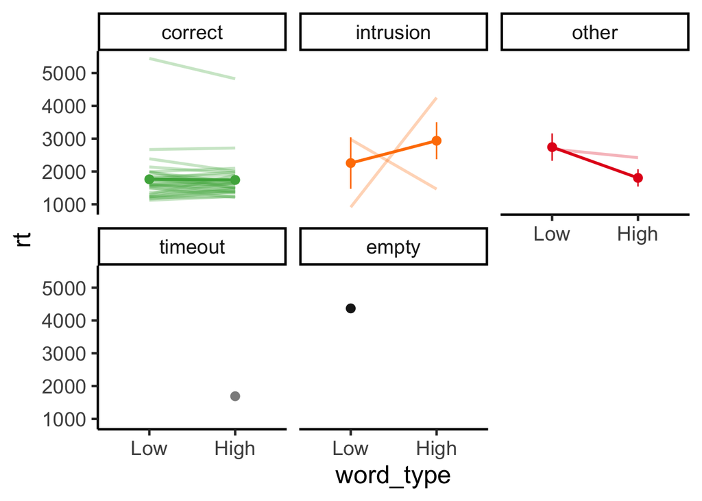

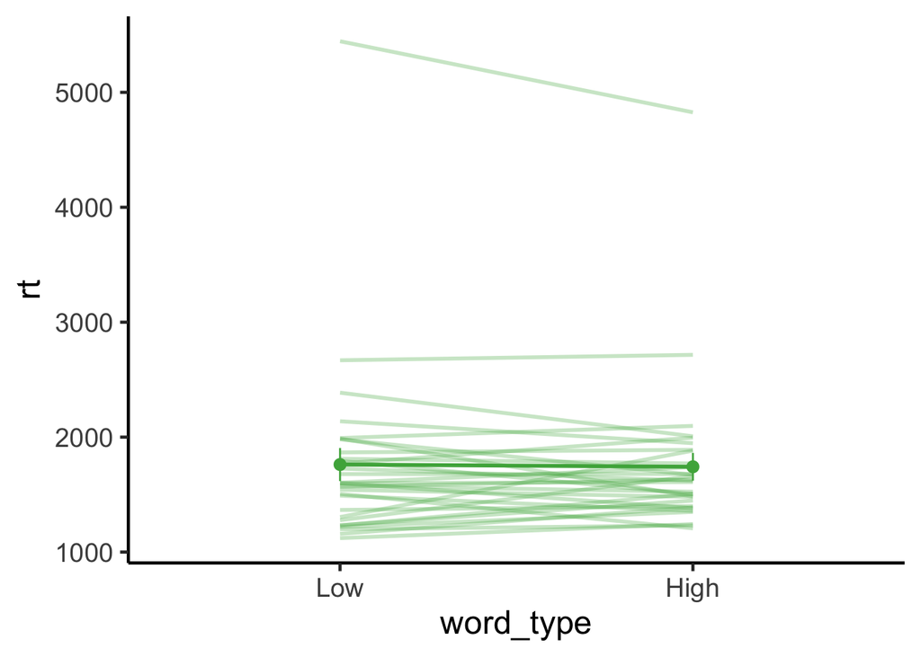

43% of participants respond faster on high memorability trials (including only correct response trials).

### Stats

```r
lmer(rt ~ word_type + (1|wid), data=trials) %>% summ
```

| Fixed Effects | Fixed Effects Est. | Fixed Effects S.E. | Fixed Effects t val. | Fixed Effects d.f. | Fixed Effects p |
| --- | --- | --- | --- | --- | --- |
| (Intercept) | 1800.171 | 120.038 | 14.997 | 28.887 | 0.000 |
| word_typeHigh | -24.460 | 57.331 | -0.427 | 506.732 | 0.670 |

p values calculated using Satterthwaite d.f.

```r
lmer(rt ~ word_type * response_type + (1|wid), data=trials) %>% summ
```

| Fixed Effects | Fixed Effects Est. | Fixed Effects S.E. | Fixed Effects t val. | Fixed Effects d.f. | Fixed Effects p |
| --- | --- | --- | --- | --- | --- |
| (Intercept) | 1723.990 | 118.398 | 14.561 | 29.474 | 0.000 |
| word_typeHigh | 19.021 | 55.743 | 0.341 | 501.636 | 0.733 |
| response_typeintrusion | 893.829 | 291.865 | 3.062 | 505.427 | 0.002 |
| response_typeother | 884.377 | 184.192 | 4.801 | 510.941 | 0.000 |
| response_typetimeout | -276.899 | 370.685 | -0.747 | 503.665 | 0.455 |
| response_typeempty | 2975.785 | 639.879 | 4.651 | 503.558 | 0.000 |
| word_typeHigh:response_typeintrusion | 456.220 | 390.321 | 1.169 | 503.583 | 0.243 |
| word_typeHigh:response_typeother | -620.626 | 318.003 | -1.952 | 504.622 | 0.052 |

p values calculated using Satterthwaite d.f.

```r
lmer(rt ~ word_type + (1|wid), data=subset(trials, correct)) %>% summ
```

| Fixed Effects | Fixed Effects Est. | Fixed Effects S.E. | Fixed Effects t val. | Fixed Effects d.f. | Fixed Effects p |
| --- | --- | --- | --- | --- | --- |
| (Intercept) | 1725.812 | 120.418 | 14.332 | 28.558 | 0.000 |
| word_typeHigh | 19.226 | 53.200 | 0.361 | 472.370 | 0.718 |

p values calculated using Satterthwaite d.f.

```r
lmer(log_recall_rt ~ word_type + (1|wid), data=subset(trials, correct)) %>% summ
```

| Fixed Effects | Fixed Effects Est. | Fixed Effects S.E. | Fixed Effects t val. | Fixed Effects d.f. | Fixed Effects p |
| --- | --- | --- | --- | --- | --- |
| (Intercept) | 7.366 | 0.049 | 150.551 | 30.027 | 0.000 |
| word_typeHigh | 0.011 | 0.026 | 0.423 | 472.862 | 0.672 |

p values calculated using Satterthwaite d.f.

## Typing time

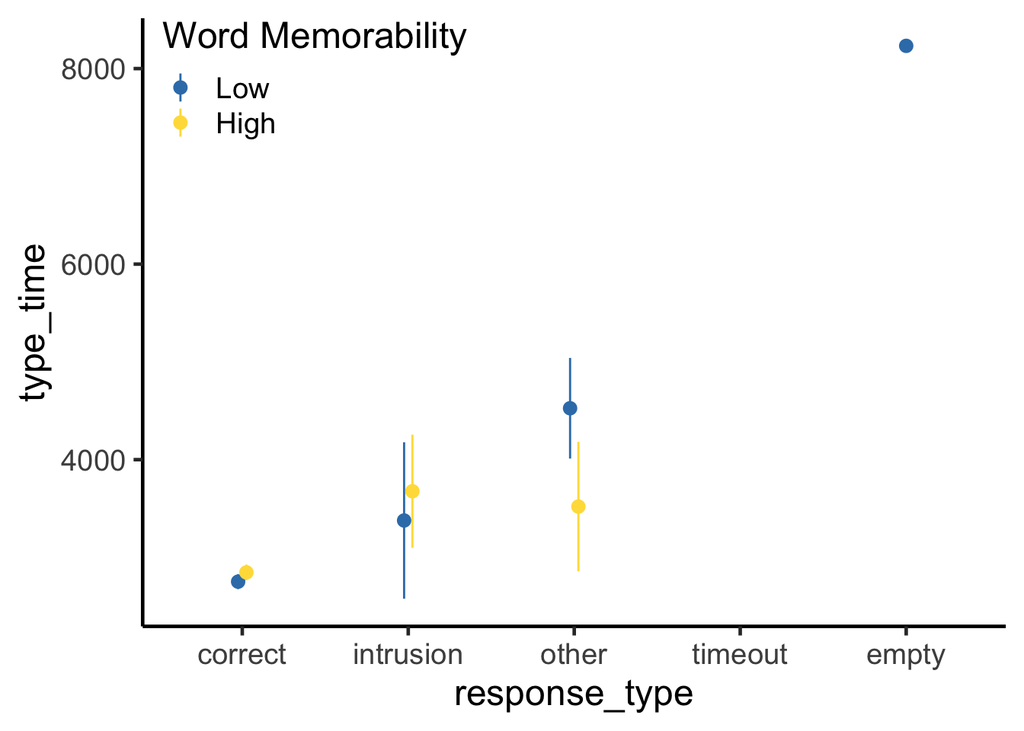

| response_type | word_type | type_time |
| --- | --- | --- |
| correct | Low | 2752.171 |
| correct | High | 2846.786 |
| intrusion | Low | 3377.764 |
| intrusion | High | 3676.773 |
| other | Low | 4525.673 |
| other | High | 3520.069 |
| timeout | High | NA |
| empty | Low | 8232.530 |

```r
lm(type_time ~ word_type, data=subset(trials, correct)) %>% summ
```

|  | Est. | S.E. | t val. | p |
| --- | --- | --- | --- | --- |
| (Intercept) | 2752.171 | 79.037 | 34.821 | 0.000 |
| word_typeHigh | 94.616 | 110.260 | 0.858 | 0.391 |

Standard errors: OLS

## Total response time

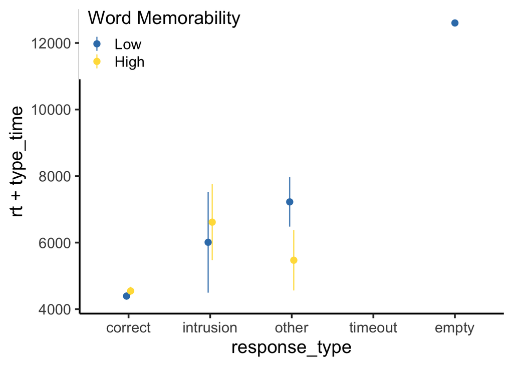

| response_type | word_type | total_time |
| --- | --- | --- |
| correct | Low | 4392.601 |
| correct | High | 4546.729 |
| intrusion | Low | 6009.164 |
| intrusion | High | 6614.273 |
| other | Low | 7223.459 |
| other | High | 5469.736 |
| timeout | High | NA |
| empty | Low | 12601.530 |

```r
lm(rt + type_time ~ word_type, data=subset(trials, correct)) %>% summ
```

|  | Est. | S.E. | t val. | p |
| --- | --- | --- | --- | --- |
| (Intercept) | 4392.601 | 118.857 | 36.957 | 0.000 |
| word_typeHigh | 154.127 | 165.811 | 0.930 | 0.353 |

Standard errors: OLS

## Check response coding

#### Responses classified as “other” (incorrect but not intrusion)

| word | response |
| --- | --- |
| dandelion | daffodil |
| tread | mark |
| barracuda | chapagie |
| grizzly | fefs |
| tread | e |
| seagull | fd |
| personnel | partner |
| goddess | superb |
| ozone | ozern |
| vagrant | vapous |
| traitor | trader |
| villain | villian |
| fellow | tranquil |
| stairs | staircases |
| house | home |
| frog | forg |
| rebel | rag |
| tread | trail |
| tread | trape |
| roost | roote |

#### Non-exact matches classified as correct

| word | response |
| --- | --- |
| villain | villai |
| volunteer | volunteee |
| barracuda | baraccuda |
| chimney | chimeny |
| barracuda | baracuda |
| shoelace | shoelaces |
| seagull | seagul |
| horse | horses |
| suburb | suburbs |
| tulip | tulips |
| critic | critc |
| bug | bugs |
| barracuda | barricuda |